# 泰坦尼克号乘员获救情况分析

## 一、项目背景

如果说现实中的Titanic是一出人间惨剧，那电影Titanic就绝对是世界电影史上的一座里程碑，它细致、真切、完整的再现了一个历史事件，  
它也用“ You Jump，I Jump ”这句台词牵动了多少男女内心深处那魂牵梦绕、念念不忘的一缕情愫。  
本项目打算从数据分析的角度，简单解析一下Titanic号上获救成员的数据，并通过这些数据找出，在所有的乘员中，什么样的人具有最高的生还率。

## 二、数据来源

本项目中的数据是从 https://www.kaggle.com/c/titanic/data 上获取的数据，数据本身相对完整，不需要再进行数据采集。

项目所用数据的主要信息如下：

| 字段 | 内容 |
| --- | --- |
| PassengerId | 乘客ID |
| Survived | 获救情况 |
| Pclass | 乘客等级 |
| Name | 乘客姓名 |
| Sex | 性别 |
| Age | 年龄 |
| SibSp | 兄弟姐妹/配偶的个数 |
| Parch | 父母/小孩的个数 |
| Ticket | 船票信息 |
| Fare | 票价 |
| Cabin | 客舱编号 |
| Embarked | 登船港口 |

数据信息的补充说明：

1. Survived：0表示未获救，1表示获救
2. Pclass：社会经济地位的表示，1等/2等/3等舱位
3. Age：年龄小于1是小数；如果年龄是估计的，它的形式是xx.5
4. SibSp：配偶部分忽略情人和未婚关系
5. Parch：对于只和保姆在一起的孩子，Parch的值为0

## 三、项目意义

本项目主要解答以下几个疑惑：

1. 在Titanic沉船事件中，男性和女性的获救情况分别是怎样的，女性是否有更高的生还几率
2. 当时乘员的年龄分布情况是怎样的，哪个年龄段的人获救比例最高
3. 大部分历史事件中，贫富差异导致的影响都是无法避免的，那么在Titanic事件中，富人和穷人生还的几率会有怎样的差别
4. 综合考虑上面几个因素，究竟什么样的人会在Titanic事件中拥有最高的生还几率

## 四、项目使用的工具

本项目使用Python语言作为分析工具，对数据进行分析和处理。主要使用numpy库包和pandas库包进行数据整理和统计分析，使用matplotlib库包实现数据的可视化以及图像的美化。

## 五、数据加载

```python
# 导入需要使用的库包

# -*- coding:utf-8 -*-
import numpy as np
import pandas as pd
import matplotlib.pyplot as plt
%matplotlib notebook
```

```python
# 导入数据
data = pd.read_csv('Titanic_data.csv')
```

```python
# 观察数据情况
data.head()
```

|  | PassengerId | Survived | Pclass | Name | Sex | Age | SibSp | Parch | Ticket | Fare | Cabin | Embarked |
| --- | --- | --- | --- | --- | --- | --- | --- | --- | --- | --- | --- | --- |
| 0 | 1 | 0 | 3 | Braund, Mr. Owen Harris | male | 22.0 | 1 | 0 | A/5 21171 | 7.2500 | NaN | S |
| 1 | 2 | 1 | 1 | Cumings, Mrs. John Bradley (Florence Briggs Th... | female | 38.0 | 1 | 0 | PC 17599 | 71.2833 | C85 | C |
| 2 | 3 | 1 | 3 | Heikkinen, Miss. Laina | female | 26.0 | 0 | 0 | STON/O2. 3101282 | 7.9250 | NaN | S |
| 3 | 4 | 1 | 1 | Futrelle, Mrs. Jacques Heath (Lily May Peel) | female | 35.0 | 1 | 0 | 113803 | 53.1000 | C123 | S |
| 4 | 5 | 0 | 3 | Allen, Mr. William Henry | male | 35.0 | 0 | 0 | 373450 | 8.0500 | NaN | S |

```python
data.info()
```

```
<class 'pandas.core.frame.DataFrame'>
RangeIndex: 891 entries, 0 to 890
Data columns (total 12 columns):
PassengerId    891 non-null int64
Survived       891 non-null int64
Pclass         891 non-null int64
Name           891 non-null object
Sex            891 non-null object
Age            714 non-null float64
SibSp          891 non-null int64
Parch          891 non-null int64
Ticket         891 non-null object
Fare           891 non-null float64
Cabin          204 non-null object
Embarked       889 non-null object
dtypes: float64(2), int64(5), object(5)
memory usage: 83.6+ KB
```

通过读取数据的信息，可以看到，数据集中共有12个字段，891条记录，其中Survived，Pclass，Sex，Age这几个字段是重点关注的对象，主要对这几个字段的记录进行分析。同时，Age和Cabin这两个字段还存在缺失值，在处理时需要注意。

## 六、数据分析

### 6.1 乘员舱位、性别和年龄的分布情况

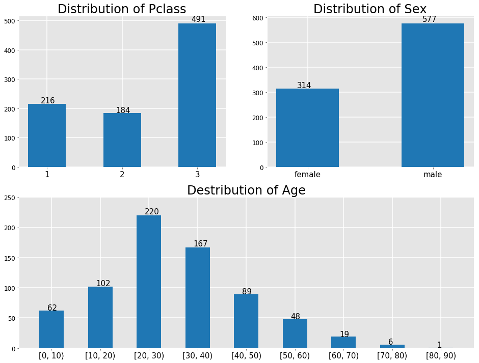

```python
# 使用'ggplot'的风格进行绘图
plt.style.use('ggplot')
# 生成用于绘制子图的图像
fig = plt.figure(figsize=(16, 12))
# 定义一个函数，设置每个刻度标签对应的数据标签
def auto_tags(rects):
    for rect in rects:
        height = rect.get_height()
        plt.text(rect.get_x() + rect.get_width()/3,
                 1.01*height, '%s'%int(height),
                 fontsize=15)


# 乘员舱位(Pclass)的分布情况
count_by_pclass = data.groupby('Pclass')['Survived'].count()
# 绘制子图
ax1 = fig.add_subplot(2, 2, 1)
rect1 = ax1.bar(np.arange(len(count_by_pclass)),
                count_by_pclass.values,
                width = 0.5,
                color = 'tab:blue')
ax1.set_title('Distribution of Pclass',fontsize=24)
ax1.set_xticks(range(0, len(count_by_pclass), 1))
ax1.set_xticklabels(count_by_pclass.index, fontsize=15, color='k')
ax1.grid(linewidth = 1.5)
plt.yticks(range(0,550,100), fontsize=12, color='k')
# 设置数据标签
auto_tags(rect1)


# 乘员性别(Sex)的分布情况
count_by_sex = data.groupby('Sex')['Survived'].count()
# 绘制子图
ax2 = fig.add_subplot(2, 2, 2)
rect2 = ax2.bar(np.arange(len(count_by_sex)),
                count_by_sex.values,
                width = 0.5,
                color = 'tab:blue')
ax2.set_title('Distribution of Sex', fontsize=24)
ax2.set_xticks(range(0, len(count_by_sex), 1))
ax2.set_xticklabels(count_by_sex.index, fontsize=15, color='k')
ax2.grid(linewidth = 1.5)
plt.yticks(range(0,650,100), fontsize=12, color='k')
# 设置数据标签
auto_tags(rect2)


# 乘员年龄(Age)的分布情况
# 对于年龄这一字段，不必关注单一年龄点的数据，而应关注每个年龄段的数据
# 这里对于年龄进行了分组，每10年为一组
# 年龄这一字段存在缺失值，先对缺失值进行清理
drop_null_age_data = data[data['Age'].notnull()]
# 重设清理后数据的索引
drop_null_age_data.index = pd.Series(range(len(drop_null_age_data)))
# 对年龄进行分段，并在数据集中添加相应的年龄区间('AgeInterval')
bins = [0, 10, 20, 30, 40, 50, 60, 70, 80, 90]
drop_null_age_data['AgeInterval']  = pd.cut(drop_null_age_data['Age'], bins, right=False)
count_by_ageitv = drop_null_age_data.groupby('AgeInterval')['Survived'].count()
# 绘制子图
ax3 = fig.add_subplot(2, 1, 2)
rect3 = ax3.bar(np.arange(len(count_by_ageitv)),
                count_by_ageitv.values,
                width = 0.5,
                color = 'tab:blue')
ax3.set_title('Destribution of Age', fontsize=24)
ax3.set_xticks(range(0, len(count_by_ageitv), 1))
ax3.set_xticklabels(count_by_ageitv.index, fontsize=15, color='k')
ax3.grid(linewidth = 1.5)
plt.yticks(range(0,270,50), fontsize=12, color='k')
# 设置数据标签
auto_tags(rect3)

# 调整子图周围的间距
#plt.subplots_adjust(hspace=0.5)
```

上图向我们展示了Titanic的乘员关于舱位、性别和年龄的分布情况：

1. 一等舱的乘员人数为216人，二等舱为184人，三等舱为491人。
2. 女性乘员为314人，男性乘员为577人，男性人数远多于女性。
3. 乘员的年龄分布呈现中间多、两头少的形态，比较接近正态分布。
4. 在所有乘员中，20-30岁年龄段的人数最多，为220人；80-90岁年龄段人数最少，只有1人。**要注意的是，这里对年龄的数据中存在的缺失值进行了清理，所以按年龄分组的数据总和是714，是小于总记录数891的**。

### 6.2 不同性别的乘员的获救情况

在6.1中已对性别这一字段分组并按分组进行了计数统计，可以直接使用相关的数据：  
count_by_sex = data.groupby('Sex')['Survived'].count()

```python
count_by_sex
```

```
Sex
female    314
male      577
Name: Survived, dtype: int64
```

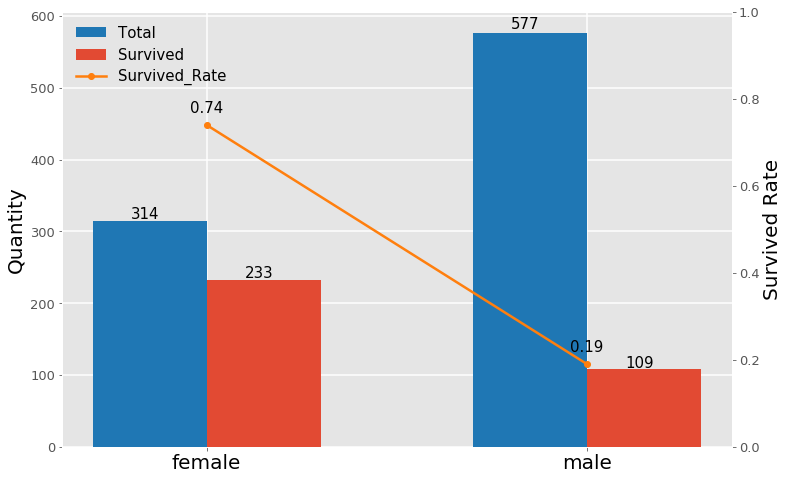

```python
# 统计获救乘员的性别分布
survived_by_sex = data.groupby('Sex')['Survived'].sum()
# 绘制图像
fig = plt.figure(figsize=(12, 8))
ax1 = fig.add_subplot(1, 1, 1)
rect = ax1.bar([0, 1],
               count_by_sex.values,
               width=0.3,
               align='edge',
               color='tab:blue',
               label='Total')
rect1 = ax1.bar([0.3, 1.3],
                survived_by_sex.values,
                width=0.3,
                align='edge',
                label='Survived')
ax1.set_ylabel('Quantity', fontsize=20, color='k')
ax1.set_xticks([0.3,1.3])
ax1.set_xticklabels(count_by_sex.index, fontsize=20, color='k')
ax1.grid(linewidth=1.5)
plt.yticks(range(0, 650, 100), fontsize=13)
plt.legend(loc='upper left', fontsize=15, frameon=False)
# 设置数据标签
auto_tags(rect)
auto_tags(rect1)

# 根据性别计算生还率
survived_rate_by_sex = (survived_by_sex.apply(float) / count_by_sex.apply(float)).round(2)
# 绘制图像
ax2 = ax1.twinx()
x = [0.3, 1.3]
y = survived_rate_by_sex.values
plot = ax2.plot(x,
                y,
                color='tab:orange',
                marker='o',
                markersize=6,
                linewidth=2.5,
                label='Survived_Rate')
ax2.set_ylabel('Survived Rate', fontsize=20, color='k')
plt.yticks(np.arange(0, 1.2, 0.2), fontsize=13)
plt.legend(loc='upper left', fontsize=15, frameon=False, bbox_to_anchor=(0, 0.9))
plt.grid(False)
# 设置数据标签
for x, y in zip(x, y):
    plt.text(x-0.045, y+0.029, str(y), fontsize=15)
```

从上图可以看出：

1. 在有记录的所有乘员中，女性为314人，男性为577人。
2. 而在生还的乘员中，女性为233人，男性为109人。
3. 从生还率来看，女性为74%，男性为19%。
4. 女性和男性在获救情况上的巨大差异，让我们可以相信**在Titanic沉船后的逃生过程中，“女士优先”这一道德准则被坚定的执行了，因此女性乘员获得了更多的生还机会。**

### 6.3 不同年龄段的乘员的获救情况

在6.1中已对年龄这一字段进行了清理、分组并按分组进行了计数统计，可以直接使用相关的数据：  
drop_null_age_data = data[data['Age'].notnull()]  
drop_null_age_data.index = pd.Series(range(len(drop_null_age_data)))  
bins = [0, 10, 20, 30, 40, 50, 60, 70, 80, 90]  
drop_null_age_data['AgeInterval'] = pd.cut(drop_null_age_data['Age'], bins, right=False)  
count_by_ageitv = drop_null_age_data.groupby('AgeInterval')['Survived'].count()

```python
drop_null_age_data.head()
```

|  | PassengerId | Survived | Pclass | Name | Sex | Age | SibSp | Parch | Ticket | Fare | Cabin | Embarked | AgeInterval |
| --- | --- | --- | --- | --- | --- | --- | --- | --- | --- | --- | --- | --- | --- |
| 0 | 1 | 0 | 3 | Braund, Mr. Owen Harris | male | 22.0 | 1 | 0 | A/5 21171 | 7.2500 | NaN | S | [20, 30) |
| 1 | 2 | 1 | 1 | Cumings, Mrs. John Bradley (Florence Briggs Th... | female | 38.0 | 1 | 0 | PC 17599 | 71.2833 | C85 | C | [30, 40) |
| 2 | 3 | 1 | 3 | Heikkinen, Miss. Laina | female | 26.0 | 0 | 0 | STON/O2. 3101282 | 7.9250 | NaN | S | [20, 30) |
| 3 | 4 | 1 | 1 | Futrelle, Mrs. Jacques Heath (Lily May Peel) | female | 35.0 | 1 | 0 | 113803 | 53.1000 | C123 | S | [30, 40) |
| 4 | 5 | 0 | 3 | Allen, Mr. William Henry | male | 35.0 | 0 | 0 | 373450 | 8.0500 | NaN | S | [30, 40) |

```python
count_by_ageitv
```

```
AgeInterval
[0, 10)      62
[10, 20)    102
[20, 30)    220
[30, 40)    167
[40, 50)     89
[50, 60)     48
[60, 70)     19
[70, 80)      6
[80, 90)      1
Name: Survived, dtype: int64
```

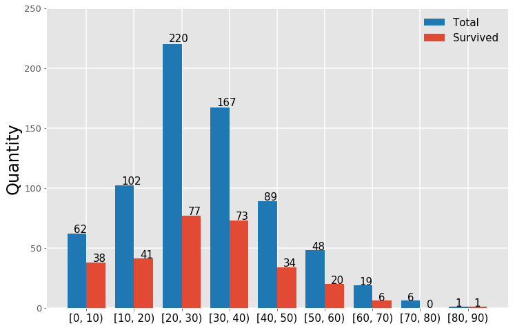

```python
# 统计获救乘员的年龄分布
survived_by_ageitv = drop_null_age_data.groupby('AgeInterval')['Survived'].sum()
# 绘制图像
fig = plt.figure(figsize=(12, 8))
ax1 = fig.add_subplot(1, 1, 1)
rect = ax1.bar(np.arange(len(count_by_ageitv)),
               count_by_ageitv.values,
               width=0.4,
               color='tab:blue',
               align='edge',
               label='Total')
x = [0.4 + i for i in range(len(count_by_ageitv))]
rect1 = ax1.bar(x,
                survived_by_ageitv.values,
                width=0.4,
                align='edge',
                label='Survived')
ax1.set_xticks(x)
ax1.set_xticklabels(count_by_ageitv.index, fontsize=15, color='k')
ax1.set_ylabel('Quantity', fontsize=24, color='k')
ax1.grid(linewidth=1.5)
plt.yticks(range(0, 270, 50), fontsize=13)
plt.legend(loc='upper right', fontsize=15, frameon=False)
# 设置数据标签
auto_tags(rect)
auto_tags(rect1)
```

从上图可以看出：

1. 获救乘员的年龄分布与总乘员的年龄分布的形态比较相似，都是中间高两边低，都比较接近正态分布；
2. 虽然20~30岁年龄段的获救人数最多，但是其获救比例看起来并不比其他年龄段高，反而感觉更低。

因此，为了弄清楚的各年龄段的生还比例，接下来进行生还率的计算并绘图。

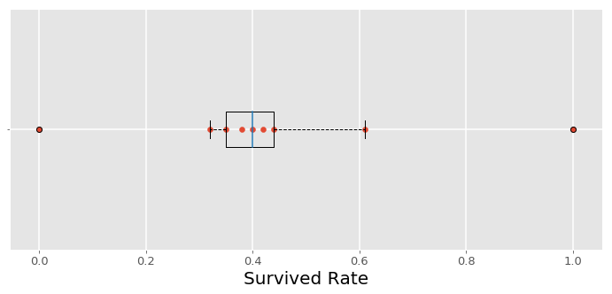

```python
# 计算生还率
survived_rate_by_age = (survived_by_ageitv.apply(float) / count_by_ageitv.apply(float)).round(2)
# 绘制图像
fig = plt.figure(figsize=(12, 5))
ax1 = fig.add_subplot(1, 1, 1)
box = ax1.boxplot(survived_rate_by_age.values,
                  medianprops={'color':'tab:blue','linewidth':1.5},
                  whis=2, # whis: IQR，默认1.5，也可以设置区间比如[5,95]，代表强制上下边缘为数据95%和5%位置
                  whiskerprops={'linestyle':'--'},
                  vert=False)
y = [1 for i in range(len(survived_rate_by_age))]
scatter = ax1.scatter(survived_rate_by_age.values, y)
ax1.set_yticklabels('')
ax1.set_xlabel('Survived Rate', fontsize=20, color='k')
plt.xticks(np.arange(0, 1.2, 0.2), fontsize=13)
plt.grid(linewidth=1.5)
```

从上面的箱型图和散点图可以看出：

1. 按年龄分段计算出的生还率大部分集中在0.3-0.6的范围内。
2. 存在两个极值点，0和1。一般来说，生还率是0到1之间的某个值，基本不会取到0或1这两个值，所以这两个极值是有问题的。

为了搞清楚问题所在，进一步画出折线图：

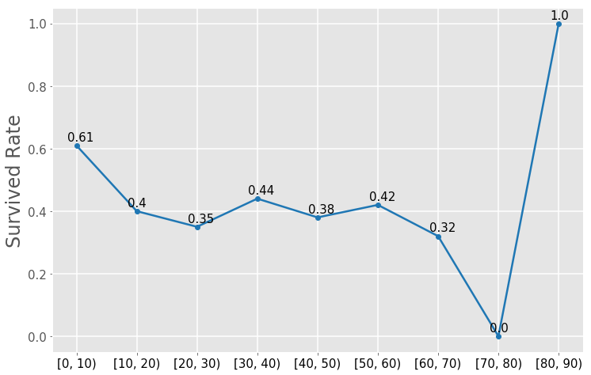

```python
# 绘制图像
fig = plt.figure(figsize=(12, 8))
ax1 = fig.add_subplot(1, 1, 1)
x = [i for i in np.arange(len(survived_rate_by_age))]
y = survived_rate_by_age.values
plot = ax1.plot(x,
                y,
                color='tab:blue',
                marker='o',
                markersize=6,
                linewidth=2.5)
ax1.set_xticks(range(len(survived_rate_by_age)))
ax1.set_xticklabels(survived_rate_by_age.index, fontsize=15, color='k')
ax1.set_ylabel('Survived Rate', fontsize=24)
plt.yticks(np.arange(0, 1.2, 0.2), fontsize=15)
plt.grid(linewidth=1.5)
# 设置数据标签
for  x, y in zip(x, y):
    plt.text(x-0.15, y+0.015, str(y), fontsize=15)
```

从折线图可以看出，两个极值点对应的年龄段为70-80和80-90。参考之前的条形图，这两个年龄段的总人数分别是6人和1人，**用于计算的基数太小，可以认为对于这两个年龄段，计算出的生还率并不具备显著的统计学意义**。在分析的时候可以忽略。

对于其他年龄段的信息，可以得出以下结论：

1. 0-10岁（儿童）的生还率最高，达到了61%；
2. 60-70岁（老年人）的生还率最低，只有32%；
3. 10-60岁（青壮年）的生还率在35%-45%之间，其中最低的生还率是35%，是20-30岁的人群。

按常理来说，由于生理上的优势，青壮年在面对灾难时，他们的生还率是要高于儿童和老人的。但是通过上面的图示和分析，可以看到在Titanic沉船事件中，事实却并不如通常所设想的那样。  
对于不同年龄段的乘员的获救情况，我的看法如下：

- 0-10岁的儿童的生还率远高于其他年龄段，但是儿童并不具备充分的自救能力。所以说，**在Titanic沉船后的逃生过程中，儿童受到明显的优待，因此其生还率远高于其他年龄段。**
- 60-70岁的老年人生还率较低，可以从两个方面解释。  
  一、这个年龄段的老年人在生理上处于衰弱期，可能还伴有疾病，即便获得了逃生的机会也难于幸存；  
  二、在数据集中这个年龄段的人数只有19人，基数偏小，因此计算得出的生还率受随机因素影响较大，代表性不强。
- 最超出预料的就是20-30岁这个年龄段的数据。  
  一般来讲，20-30岁正处于一个人生理和体能的巅峰阶段，按照常理推断，在灾难中这个年龄段的生还率应该是最高的，但是在本数据集中，这个年龄段的生还率只有35%，属于较低水平。  
  **20-30岁的人，或许正是年轻热血的时期，面对灾难，许多人会像电影里的主角Jack一样，将生还的机会让给自己的爱人、亲人或者朋友。**

### 6.4 不同阶层的乘员的获救情况

这里的阶层是指，按经济地位决定的阶层，具体则由舱位来体现，并不泛指。  
在6.1中已对舱位这一字段分组并按分组进行了计数统计，可以直接使用相关的数据：  
count_by_pclass = data.groupby('Pclass')['Survived'].count()

```python
count_by_pclass
```

```
Pclass
1    216
2    184
3    491
Name: Survived, dtype: int64
```

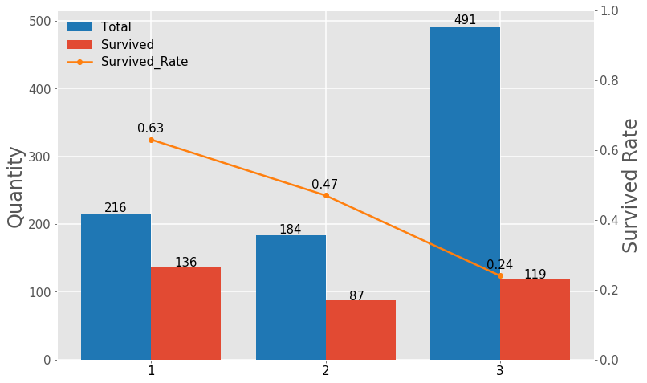

```python
# 统计获救乘员的舱位分布
survived_by_pclass = data.groupby('Pclass')['Survived'].sum()
# 绘制图像
fig = plt.figure(figsize=(12, 8))
ax1 = fig.add_subplot(1, 1, 1)
rect = ax1.bar(np.arange(len(count_by_pclass)),
               count_by_pclass.values,
               width=0.4,
               color='tab:blue',
               align='edge',
               label='Total')
x = [0.4 + i for i in range(len(survived_by_pclass))]
rect1 = ax1.bar(x,
                survived_by_pclass.values,
                width=0.4,
                align='edge',
                label='Survived')
ax1.set_ylabel('Quantity', fontsize=24)
ax1.set_xticks(x)
ax1.set_xticklabels(survived_by_pclass.index, fontsize=15, color='k')
plt.yticks(range(0, 550, 100), fontsize=15)
plt.grid(linewidth=1.5)
plt.legend(loc='upper left', fontsize=15, frameon=False)
# 设置数据标签
auto_tags(rect)
auto_tags(rect1)

# 计算生还率
survived_rate_by_pclass = (survived_by_pclass.apply(float) / count_by_pclass.apply(float)).round(2)
# 绘制图像
ax2 = ax1.twinx()
y = survived_rate_by_pclass.values
plot = ax2.plot(x,
                y,
                color='tab:orange',
                linewidth=2.5,
                marker='o',
                markersize=6,
                label='Survived_Rate')
ax2.set_ylabel('Survived Rate', fontsize=24)
plt.yticks(np.arange(0, 1.2, 0.2), fontsize=15)
plt.grid(False)
plt.legend(loc='upper left', fontsize=15, frameon=False, bbox_to_anchor=(0, 0.9))
# 设置数据标签
for x, y in zip(x, y):
    plt.text(x-0.08, y+0.02, str(y), fontsize=15)
```

从上图可以看出：

1. 从乘员人数来看，最多的舱位为三等舱，其次一等舱，最少的为二等舱；
2. 从生还人数来看，最多的为一等舱，其次三等舱，最少的为二等舱；
3. 从生还比例来看，**最高的生还比例是63%，为一等舱；其次是47%，为二等舱；最低的生还比例只有24%，为三等舱。** 一等舱乘员的生还率是三等舱的2.6倍还多，二等舱乘员的生还率接近三等舱的2倍。
4. 考虑到舱位等级背后所代表的贫富差异，可以这么说：**在Titanic沉船事件中，相对富有的人（一等舱乘员）的生还率远远高于相对贫穷的人（三等舱乘员）。贫富差异不仅造成了生活机会的差距，甚至直接导致了生存机会的差距，这在Titanic沉船事件中体现的无以复加。**

### 6.5 综合考量，乘员的获救情况

从多个角度对乘员的生还率进行分析，找出生还率最高的人群。  
在这里，综合考量的是**性别、舱位和年龄**这三个因素。

```python
drop_null_age_data.head()
```

|  | PassengerId | Survived | Pclass | Name | Sex | Age | SibSp | Parch | Ticket | Fare | Cabin | Embarked | AgeInterval |
| --- | --- | --- | --- | --- | --- | --- | --- | --- | --- | --- | --- | --- | --- |
| 0 | 1 | 0 | 3 | Braund, Mr. Owen Harris | male | 22.0 | 1 | 0 | A/5 21171 | 7.2500 | NaN | S | [20, 30) |
| 1 | 2 | 1 | 1 | Cumings, Mrs. John Bradley (Florence Briggs Th... | female | 38.0 | 1 | 0 | PC 17599 | 71.2833 | C85 | C | [30, 40) |
| 2 | 3 | 1 | 3 | Heikkinen, Miss. Laina | female | 26.0 | 0 | 0 | STON/O2. 3101282 | 7.9250 | NaN | S | [20, 30) |
| 3 | 4 | 1 | 1 | Futrelle, Mrs. Jacques Heath (Lily May Peel) | female | 35.0 | 1 | 0 | 113803 | 53.1000 | C123 | S | [30, 40) |
| 4 | 5 | 0 | 3 | Allen, Mr. William Henry | male | 35.0 | 0 | 0 | 373450 | 8.0500 | NaN | S | [30, 40) |

```python
# 按性别、舱位、年龄分组，并分别统计分组总人数和生还人数
count_by = drop_null_age_data.groupby(['Sex', 'Pclass', 'AgeInterval'])['Survived'].count()
survived_by = drop_null_age_data.groupby(['Sex', 'Pclass', 'AgeInterval'])['Survived'].sum()
# 计算生还率
survived_rate = (survived_by.apply(float) / count_by.apply(float)).round(2)
```

```python
# 转换数据类型，更改列名，增加新的列
count_df = pd.DataFrame(count_by)
count_df.columns = ['Count']
count_df['SurvivedRate'] = survived_rate.values
```

```python
# 按生还率排序
sorted_df = count_df.sort_values('SurvivedRate', ascending=False)
sorted_df
```

| Sex | Pclass | AgeInterval | Count | SurvivedRate |
| --- | --- | --- | --- | --- |
| female | 3 | [60, 70) | 1 | 1.00 |
|  | 1 | [60, 70) | 3 | 1.00 |
| male | 1 | [80, 90) | 1 | 1.00 |
|  | 2 | [0, 10) | 9 | 1.00 |
|  | 1 | [0, 10) | 2 | 1.00 |
| female | 2 | [0, 10) | 8 | 1.00 |
|  |  | [10, 20) | 8 | 1.00 |
|  | 1 | [40, 50) | 13 | 1.00 |
|  |  | [30, 40) | 27 | 1.00 |
|  |  | [10, 20) | 13 | 1.00 |
|  | 2 | [30, 40) | 17 | 0.94 |
|  | 1 | [20, 30) | 16 | 0.94 |
|  |  | [50, 60) | 12 | 0.92 |
|  | 2 | [40, 50) | 10 | 0.90 |
|  |  | [20, 30) | 25 | 0.88 |
|  |  | [50, 60) | 6 | 0.83 |
|  | 3 | [10, 20) | 24 | 0.54 |
| male | 1 | [30, 40) | 23 | 0.52 |
| female | 3 | [0, 10) | 21 | 0.52 |
| male | 1 | [20, 30) | 18 | 0.50 |
| female | 3 | [20, 30) | 31 | 0.48 |
|  |  | [30, 40) | 16 | 0.44 |
| male | 1 | [10, 20) | 5 | 0.40 |
|  | 3 | [0, 10) | 21 | 0.38 |
|  | 1 | [40, 50) | 24 | 0.38 |
|  | 2 | [60, 70) | 3 | 0.33 |
|  | 1 | [50, 60) | 15 | 0.27 |
|  | 3 | [20, 30) | 102 | 0.16 |
|  |  | [30, 40) | 53 | 0.15 |
|  | 2 | [40, 50) | 8 | 0.12 |
|  | 1 | [60, 70) | 10 | 0.10 |
|  | 2 | [10, 20) | 10 | 0.10 |
|  |  | [30, 40) | 31 | 0.10 |
|  | 3 | [10, 20) | 42 | 0.10 |
|  |  | [40, 50) | 25 | 0.08 |
|  |  | [50, 60) | 6 | 0.00 |
|  |  | [60, 70) | 2 | 0.00 |
| female | 1 | [0, 10) | 1 | 0.00 |
| male | 2 | [70, 80) | 1 | 0.00 |
|  |  | [50, 60) | 9 | 0.00 |
|  |  | [20, 30) | 28 | 0.00 |
|  | 1 | [70, 80) | 3 | 0.00 |
| female | 3 | [40, 50) | 9 | 0.00 |
| male | 3 | [70, 80) | 2 | 0.00 |

```python
# 筛选出生还率在80%以上的数据
high_rate_df = count_df[count_df['SurvivedRate'] > 0.8]
high_rate_df
```

| Sex | Pclass | AgeInterval | Count | SurvivedRate |
| --- | --- | --- | --- | --- |
| female | 1 | [10, 20) | 13 | 1.00 |
|  |  | [20, 30) | 16 | 0.94 |
|  |  | [30, 40) | 27 | 1.00 |
|  |  | [40, 50) | 13 | 1.00 |
|  |  | [50, 60) | 12 | 0.92 |
|  |  | [60, 70) | 3 | 1.00 |
|  | 2 | [0, 10) | 8 | 1.00 |
|  |  | [10, 20) | 8 | 1.00 |
|  |  | [20, 30) | 25 | 0.88 |
|  |  | [30, 40) | 17 | 0.94 |
|  |  | [40, 50) | 10 | 0.90 |
|  |  | [50, 60) | 6 | 0.83 |
|  | 3 | [60, 70) | 1 | 1.00 |
| male | 1 | [0, 10) | 2 | 1.00 |
|  |  | [80, 90) | 1 | 1.00 |
|  | 2 | [0, 10) | 9 | 1.00 |

```python
# 筛除统计基数过小的数据
high_rate_df[high_rate_df['Count'] > 5]
```

| Sex | Pclass | AgeInterval | Count | SurvivedRate |
| --- | --- | --- | --- | --- |
| female | 1 | [10, 20) | 13 | 1.00 |
|  |  | [20, 30) | 16 | 0.94 |
|  |  | [30, 40) | 27 | 1.00 |
|  |  | [40, 50) | 13 | 1.00 |
|  |  | [50, 60) | 12 | 0.92 |
|  | 2 | [0, 10) | 8 | 1.00 |
|  |  | [10, 20) | 8 | 1.00 |
|  |  | [20, 30) | 25 | 0.88 |
|  |  | [30, 40) | 17 | 0.94 |
|  |  | [40, 50) | 10 | 0.90 |
|  |  | [50, 60) | 6 | 0.83 |
| male | 2 | [0, 10) | 9 | 1.00 |

从上述的分析结果，可以看出：

1. 一等舱的乘员中，年龄10-60岁之间的女性具有最高的生还率，在90%以上；
2. 二等舱的乘员中，年龄0-60岁之间的女性具很高的生还率，在80%以上；
3. 男性乘员中，只有儿童（10岁以下）具有非常高的生还率。乘坐二等舱的男性儿童生还率近乎100%。

这里只对生还率比较高的乘员进行了分析，接下来绘制图像来看看所有乘员分组后的生还率的分布情况。

```python
count_df['SurvivedRate']
```

```
Sex     Pclass  AgeInterval
female  1       [0, 10)        0.00
                [10, 20)       1.00
                [20, 30)       0.94
                [30, 40)       1.00
                [40, 50)       1.00
                [50, 60)       0.92
                [60, 70)       1.00
        2       [0, 10)        1.00
                [10, 20)       1.00
                [20, 30)       0.88
                [30, 40)       0.94
                [40, 50)       0.90
                [50, 60)       0.83
        3       [0, 10)        0.52
```

[output cut: 31 more lines]

```python
# 对数据进行重塑，将行中的数据透视到列
unstack_by_sex_df = count_df['SurvivedRate'].unstack(0)
unstack_by_sex_df
```

| Pclass | Sex AgeInterval | female | male |
| --- | --- | --- | --- |
| 1 | [0, 10) | 0.00 | 1.00 |
|  | [10, 20) | 1.00 | 0.40 |
|  | [20, 30) | 0.94 | 0.50 |
|  | [30, 40) | 1.00 | 0.52 |
|  | [40, 50) | 1.00 | 0.38 |
|  | [50, 60) | 0.92 | 0.27 |
|  | [60, 70) | 1.00 | 0.10 |
|  | [70, 80) | NaN | 0.00 |
|  | [80, 90) | NaN | 1.00 |
| 2 | [0, 10) | 1.00 | 1.00 |
|  | [10, 20) | 1.00 | 0.10 |
|  | [20, 30) | 0.88 | 0.00 |
|  | [30, 40) | 0.94 | 0.10 |
|  | [40, 50) | 0.90 | 0.12 |
|  | [50, 60) | 0.83 | 0.00 |
|  | [60, 70) | NaN | 0.33 |
|  | [70, 80) | NaN | 0.00 |
| 3 | [0, 10) | 0.52 | 0.38 |
|  | [10, 20) | 0.54 | 0.10 |
|  | [20, 30) | 0.48 | 0.16 |
|  | [30, 40) | 0.44 | 0.15 |
|  | [40, 50) | 0.00 | 0.08 |
|  | [50, 60) | NaN | 0.00 |
|  | [60, 70) | 1.00 | 0.00 |
|  | [70, 80) | NaN | 0.00 |

```python
female_df = unstack_by_sex_df.female.unstack()
female_df
```

```
AgeInterval  [0, 10)  [10, 20)  [20, 30)  [30, 40)  [40, 50)  [50, 60)  \
Pclass
1               0.00      1.00      0.94      1.00       1.0      0.92
2               1.00      1.00      0.88      0.94       0.9      0.83
3               0.52      0.54      0.48      0.44       0.0       NaN

AgeInterval  [60, 70)  [70, 80)  [80, 90)
Pclass
1                 1.0       NaN       NaN
2                 NaN       NaN       NaN
3                 1.0       NaN       NaN
```

```python
male_df = unstack_by_sex_df.male.unstack()
male_df
```

```
AgeInterval  [0, 10)  [10, 20)  [20, 30)  [30, 40)  [40, 50)  [50, 60)  \
Pclass
1               1.00       0.4      0.50      0.52      0.38      0.27
2               1.00       0.1      0.00      0.10      0.12      0.00
3               0.38       0.1      0.16      0.15      0.08      0.00

AgeInterval  [60, 70)  [70, 80)  [80, 90)
Pclass
1                0.10       0.0       1.0
2                0.33       0.0       NaN
3                0.00       0.0       NaN
```

```
 <a list of 6 Text yticklabel objects>)
```

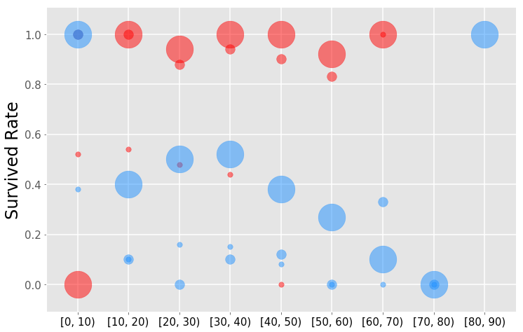

```python
# 绘制图像
fig = plt.figure(figsize=(12, 8))
ax1 = fig.add_subplot(1, 1, 1)

x1 = range(len(female_df.columns))
for i in female_df.index:
    y = female_df.loc[i].values
    scatter1 = ax1.scatter(x1, y, s=1500/(i*i*i), color='r', alpha=0.5)

x2 = range(len(male_df.columns))
for i in male_df.index:
    y = male_df.loc[i].values
    scatter2 = ax1.scatter(x2, y, s=1500/(i*i*i), color='dodgerblue', alpha=0.5)

ax1.set_xticks(x1)
ax1.set_xticklabels(female_df.columns, fontsize=15, color='k')
ax1.set_ylabel('Survived Rate', fontsize=24, color='k')
ax1.grid(linewidth=1.5)
plt.yticks(np.arange(0, 1.2, 0.2), fontsize=15)
```

上图中，横坐标为年龄段，纵坐标为生还率；红色表示女性乘员，蓝色表示男性乘员；最大的气泡表示为一等舱，其次为二等舱，最小的为三等舱。  
从图中可以看出：

1. 在10岁至70岁这个年龄段之间，大部分舱位的女性乘员的生还率都高于男性乘员。
2. 一等舱和二等舱的女性乘员，只要年龄超过10岁，其生还率基本都在80%以上。

结合上述分析可以得到这样的结论：  
在Titanic沉船事件中，生还率最高的人群为：**女性，乘坐一等舱或二等舱，年龄在10岁至70岁之间**。

## 七、总结

本项目通过对Titanic生还者数据的分析和对图像的观察，解答了在前期提出的四个疑惑。  
要说明的一点是，本项目的分析只依照数据本身展现的情况来进行的，也只体现数据之间的相关关系。在所有的分析结论中，数据之间的因果关系或者逻辑关系，仅是合理的推测，并非严格的统计论证。  
本项目只是初步探索，在Titanic号沉船事件中影响生还率的部分因素，并未进行深入的挖掘。如果继续深入，可以从构建机器学习的算法模型入手，通过数据训练模型，来预测未给出结果的乘员的生还情况。